[figure not shown]

Projet final

Dominique Lafleur, Sandrine Marcotte, Léa Simard

2024-12-02

INTRODUCTION :

La criminalité est problème croissant dans chaque grande ville du monde. Chaque crime comporte des caractéristiques démographiques et

temporels propres, ce qui nous permet de mieux analyser et prédire le comportement humain. À Los Angeles, l’étude des tendances criminelles

peut offrir des pistes d’amélioration en estimant les probabilités que de nouveaux crimes arrivent dans le futur et, donc prévenir ces futurs délits.

Ce rapport explore comment la distribution et la fréquence des crimes dans la ville de Los Angeles sont-elles influencées par les périodes, les

différents quartiers et les différentes caractéristiques des victimes. Nous cherchons, donc à répondre aux questions suivantes : • Quel est le

nombre de crimes à main armée par rapport à ceux sans arme? • Quel sont les districts plus à risque de crime avec les données de longitude et

de latitude? • Les crimes évoluent-ils au fil des années, notamment ceux liés au vol d’identité ? • Y’a-t-il des périodes de la journée où le taux de

criminalité est plus élevé? • Le taux de criminalité varie-t-il en fonction des saisons? • Quel crime est le plus fréquent dans Los Angeles? • Quels

moments de la journée ou de l’année sont les plus propices à la criminalité ? En examinant des données actualisées provenant du département de

police de Los Angeles, notre objectif est de révéler les tendances et de comprendre les variations des caractéristiques observées. Grâce à des

analyses descriptives, des visualisations, et des modèles prédictifs, ce rapport vise à connaitre quelques facteurs précis de la criminalité dans

cette métropole californienne.

DONNÉES :

Pour répondre à ces questions, nous avons utilisé un ensemble de données intitulé Los Angeles Crime Data et fourni par le département de police

de Los Angeles (LAPD). Cet ensemble de données documente avec une assez bonne précision les crimes ayant pris place dans cette ville depuis

le 10 février 2020 jusqu’à aujourd’hui. Les données, mises à jour deux fois par mois, restent actuelles et fiables, bien qu’elles aient été auparavant

actualisées chaque semaine. En raison d’un problème technique, cette fréquence a été réduite, mais le processus reste suffisamment régulier

pour garantir des informations précises et pertinente pour notre analyse. Cet ensemble de données contient à ce jour 984 045 observations et 28

variables (variables catégorielles, des variables numériques discrètes et des variables numériques continues), dont les suivantes seront

particulièrement utiles pour notre analyse :

• Date et heure du crime : pour analyser les variations temporelles.

• Quartier et coordonnées géographiques (longitude et latitude) : pour identifier les zones les plus à risque.

[figure not shown]

• Description du crime : pour catégoriser les différents types de délits.

• Sexe de la victime : pour explorer les éventuelles disparités entre hommes et femmes.

• code du crime: pour créer un prédiction selon le crime.

Ces données, à la fois qualitatives et quantitatives, représentent chaque crime par une ligne détaillant leurs caractéristiques détaillées. Cela nous

permettra de mener des analyses assez diversifiées, tels qu’une visualisation géographique, des prédictions de tendances futures et d’autres

analyses descriptives.

Par exemple, notre étude se penchera sur des aspects tels que :

• La répartition des crimes armés et non armés, selon le genre des victimes.

• L’identification des quartiers les plus à risque, avec une attention particulière à des zones comme Skid Row.

• L’évolution temporelle de délits spécifiques, tels que les vols d’identité.

• L’impact des saisons et des périodes de la journée sur la fréquence des crimes.

Cette combinaison de données et de questions offre une base solide pour comprendre les dynamiques criminelles de Los Angeles et guider les

actions futures pour offrir une sécurité publique supérieur.

ANLAYSE DES DONNÉES :

Nous commençons par charger les ‘packages’ nécessaires pour faire nos analyses. Ceux-ci sont : dplyr, ggplot2, readr, lubridate et sf.

#install.packages("sf")

#install.packages("ggplot2")

#install.packages("dplyr")

#install.packages("rnaturalearthdata")

#install.packages("rnaturalearthhires", repos = "https://ropensci.r-universe.dev", type = "source")

library(dplyr)

library(tidyverse)

library(ggplot2)

library(readr)

library(tidymodels)

[figure not shown]

library(lubridate)

library(sf)

## Warning: le package 'sf' a été compilé avec la version R 4.4.2

library(yardstick)

library(rnaturalearth)

## Warning: le package 'rnaturalearth' a été compilé avec la version R 4.4.2

[figure not shown]

library(rnaturalearthdata)

## Warning: le package 'rnaturalearthdata' a été compilé avec la version R 4.4.2

library(rnaturalearthhires)

Crime_Data_Los_Angeles <- read_csv("C:/Users/domil/OneDrive/Bureau/école/R/Crime_Data_from_2020_to_Present_20241128 (1).cs

v")

## Warning: One or more parsing issues, call `problems()` on your data frame for details,

## e.g.:

## dat <- vroom(...)

## problems(dat)

View(Crime_Data_Los_Angeles)

Ensuite, nous remarquons que cet ensemble de données compte près d’un million d’observations, donc pour le bien de la cause nous avons

décidé de seulement utilisé l’année 2021.

Crime_Data <- Crime_Data_Los_Angeles %>%

mutate(Date = as.Date(`DATE OCC`, format = "%m/%d/%Y"))

crime_data_2021 <- Crime_Data %>%

filter(format(Date, "%Y") == "2021")

View(crime_data_2021)

Pour nous aider à construire ce code nous nous sommes inspiré du site suivant : https://demandred.gitbooks.io/introduction-a-r-pour-les-

chatons/content/les-structures-de-donnees-avancees/les-dates-en-r.html (https://demandred.gitbooks.io/introduction-a-r-pour-les-

chatons/content/les-structures-de-donnees-avancees/les-dates-en-r.html)

Visualisations :

#Question 1 : Nous aimerions connaître le nombre de crimes à main armée par rapport à ceux sans arme.

Hypothèse : Nous pensons que le nombre de crimes à main armée sera plus élevé, car cela sert de force additionnelle au criminel.

[figure not shown]

Méthode : Ceci serait une de nos visualisations où on aimerait utiliser facet_grid() pour voir la proportion de crime à main armée versus sans arme

sur les femmes et sur les hommes.

non_armed_weapons <- c("NA", "VERBAL THREAT", "VEHICLE", "STRONG-ARM (HANDS, FIST, FEET OR BODILY FORCE)", "PHYSICAL PRESENC

E", "LIQUOR/DRUGS", "DOG/ANIMAL (SIC ANIMAL ON)", "DEMAND NOTE" )

armed_crime_data_2021 <- crime_data_2021%>%

mutate(armed = ifelse(`Weapon Desc` %in% non_armed_weapons, "Unarmed", "Armed"))%>%

filter(`Vict Sex` %in% c("F", "M"))

ggplot(armed_crime_data_2021, aes(x = armed)) +

geom_bar() +

facet_grid(~ `Vict Sex`) +

labs(title = "Comparaison des crimes armés et non armés par rapport au sexe des victimes",

x = "Type de crime",

y = "Nombre de crimes")

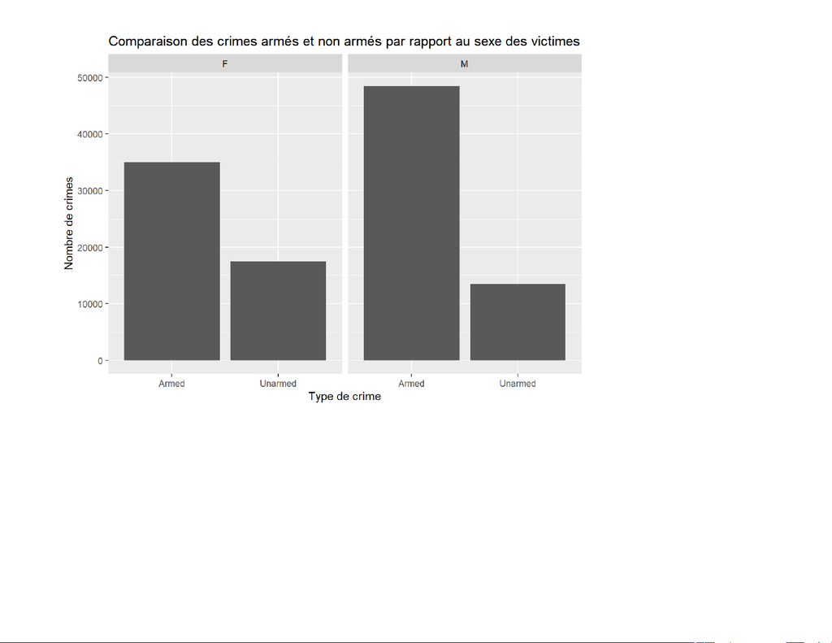

Analyse du résultat de la question 1 :

Après analyse de nos résultats, nous réalisons qu’il y a beaucoup plus de crime à main armé que de crime non-armé. En comparant les différents

sexes des victimes, on s’apercoit qu’il y a plus de crime à main armé chez les hommes et plus de crimes non armé chez les femmes. De plus, on

peut également observé qu’il y a plus de victime de sexe Male que de victime de sexe Femme.

#Question 2 : Nous voudrions connaître les districts plus à risque de crime avec les données de longitude et de latitude. Hypothèse : Nous

pensons que les quartiers plus démunis seront plus à risque. Selon La Presse, le quartier le plus démuni de Los Angeles est « Skid Row », qui

appartient au district « Central division » (https://manhattan.institute/article/the-moral-crisis-of-skid-row-las-most-notorious-neighborhood

(https://manhattan.institute/article/the-moral-crisis-of-skid-row-las-most-notorious-neighborhood)), soit « Central » dans la base de données. (Lien :

https://www.lapresse.ca/international/etats-unis/la-presse-en-californie/au-coeur-de-la-crise-americaine-de-l-itinerance/2024-06-14/des-trottoirs-

[figure not shown]

couverts-de-tentes.php# (https://www.lapresse.ca/international/etats-unis/la-presse-en-californie/au-coeur-de-la-crise-americaine-de-l-

itinerance/2024-06-14/des-trottoirs-couverts-de-tentes.php#):~:text=

(Los%20Angeles%2C%20quartier%20Skid%20Row,des%20palaces%20de%20Beverly%20Hills)

Méthode : Ceci serait notre deuxième visualisation et on voudrait faire un nuage de point pour idéalement représenter une carte à l’aide des

coordonnées de longitude et de latitude tel que mentionné précédemment.

california <- ne_states(country = "United States of America", returnclass = "sf") %>%

filter(name == "California")

ocean <- ne_download(scale = 10, type = "ocean", category = "physical", returnclass = "sf")

## Reading layer `ne_10m_ocean' from data source

## `C:\Users\domil\AppData\Local\Temp\RtmpsJceqi\ne_10m_ocean.shp'

## using driver `ESRI Shapefile'

## Simple feature collection with 1 feature and 3 fields

## Geometry type: MULTIPOLYGON

## Dimension: XY

## Bounding box: xmin: -180 ymin: -85.22194 xmax: 180 ymax: 90

## Geodetic CRS: WGS 84

xlim = c(-118.7, -118)

ylim = c(33.7, 34.35)

ggplot() +

geom_sf(data = california) +

geom_sf(data = ocean, colour='lightblue', fill='lightblue') +

coord_sf(xlim = xlim, ylim = ylim) +

theme_minimal()

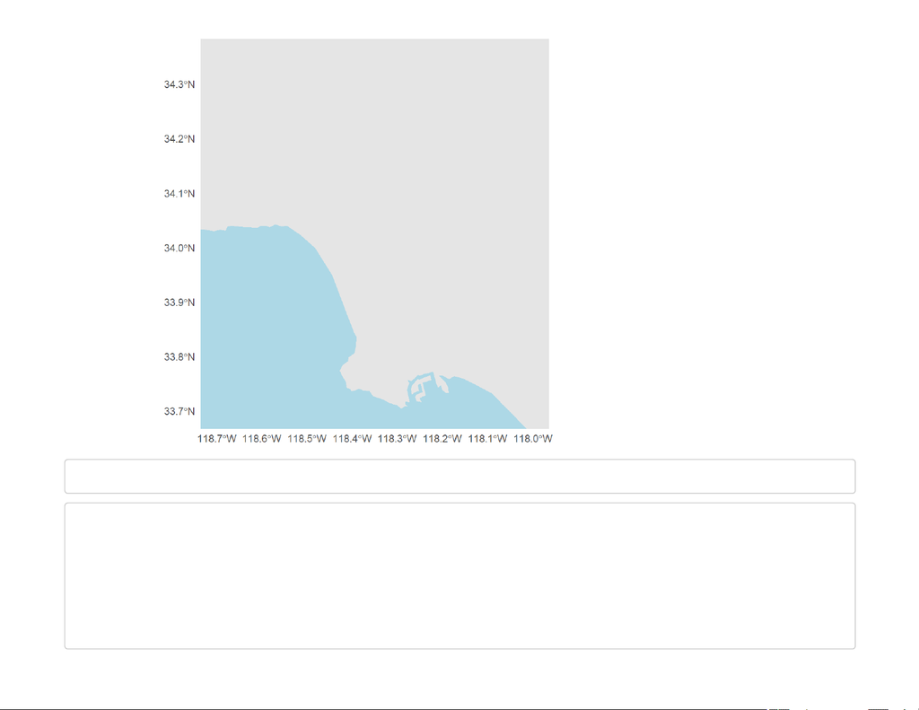

LAPD_Divisions <- st_read("R_cartes/LAPD_Divisions/LAPD_Divisions.shp")

## `C:\Users\domil\OneDrive\Bureau\école\R\R_cartes\LAPD_Divisions\LAPD_Divisions.shp'

## using driver `ESRI Shapefile'

## Simple feature collection with 21 features and 4 fields

## Geometry type: POLYGON

## Dimension: XY

## Bounding box: xmin: 6359577 ymin: 1714641 xmax: 6514633 ymax: 1945515

## Projected CRS: NAD83 / California zone 5 (ftUS)

[figure not shown]

LAPD_Reporting_Districts <- st_read("R_cartes/LAPD_Reporting_Districts/LAPD_Reporting_Districts.shp")

## `C:\Users\domil\OneDrive\Bureau\école\R\R_cartes\LAPD_Reporting_Districts\LAPD_Reporting_Districts.shp'

## using driver `ESRI Shapefile'

## Simple feature collection with 1135 features and 9 fields

## Geometry type: MULTIPOLYGON

## Dimension: XY

## Bounding box: xmin: -13210080 ymin: 3989079 xmax: -13153000 ymax: 4074185

## Projected CRS: WGS 84 / Pseudo-Mercator

LA_roads <- st_read("R_cartes/Master_Plan_of_Highways/Master_Plan_of_Highways.shp")

## `C:\Users\domil\OneDrive\Bureau\école\R\R_cartes\Master_Plan_of_Highways\Master_Plan_of_Highways.shp'

## using driver `ESRI Shapefile'

## Simple feature collection with 3952 features and 5 fields

## Geometry type: MULTILINESTRING

## Dimension: XY

## Bounding box: xmin: 6275463 ymin: 1715874 xmax: 6666506 ymax: 2121184

## Projected CRS: NAD83 / California zone 5 (ftUS)

LA_highways <- LA_roads %>%

separate(HCODE_NAME, into = c("type", "existing"), sep = " - ", remove = FALSE) %>%

filter(existing == "EXISTING",

type == "FREEWAY")

crime_sf <- st_as_sf(

crime_data_2021,

coords = c("LON", "LAT"),

crs = 4326

)

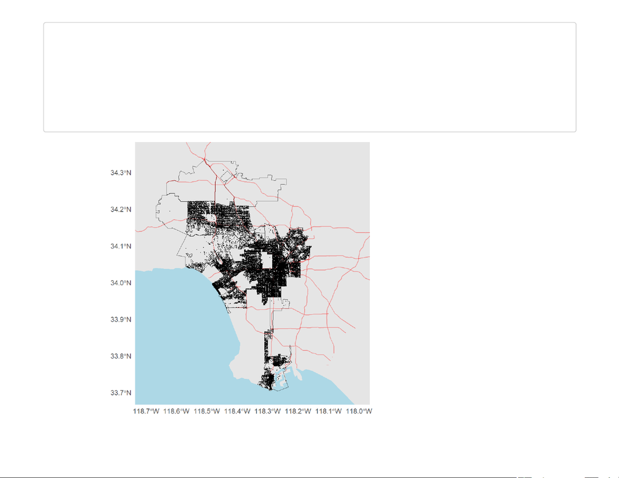

ggplot() +

geom_sf(data = california) +

geom_sf(data = ocean, colour='lightblue', fill='lightblue') +

geom_sf(data = LAPD_Divisions, fill = NA, color=alpha("black",0.7)) +

#geom_sf(data = LAPD_Reporting_Districts, fill = NA, color = "red", alpha=0.4) +

geom_sf(data = LA_highways, size=0.5, color=alpha("red",0.2)) +

geom_sf(data = crime_sf, size = 0.00005, alpha = 0.7)+

coord_sf(xlim = xlim, ylim = ylim) +

theme_minimal()

Après analyse de nos résultats, nous réalisons que les crimes sont majoritairement concentrés dans les districts de « Central Division » et de

« Newton Division ». Cela est observable grâce à la forte concentration de coordonnées créées à partir de la longitude et de la latitude.

[figure not shown]

##Statistique prédictive :

#Question 3 : Quand (jour ou nuit) chaque type de crime est le plus probable de se produire?

Hypothèse: Nous pensons que la majorité des crimes se produisent de nuit, car nous pensons qu’il y a moins de surveillance.

Méthode: Faire une regression logistique pour calculer le pourcentage de chance qu’un crime, ici le vol de voiture, se produisent de nuit.

crime_data_2021_2 <- Crime_Data %>%

filter(format(Date, "%Y") == "2021") %>%

mutate(`TIME OCC` = as.numeric(`TIME OCC`),

time = ifelse(`TIME OCC` < 600 | `TIME OCC` >= 1800, "1", "0"),

time = as.factor(time),

Crm.Cd = as.factor(`Crm Cd`)) %>%

filter(!is.na(time), !is.na(Crm.Cd), !(Crm.Cd %in% c(347, 435, 436, 444, 452, 470, 474, 906, 924, 948)))

Nous avons éliminer certains crime de Crm.Cd parce que ces crimes se sont produit qu’une fois pendant l’année 2021 et en les enlevant cela

facilite la séparation des données pour l’analyse.

crime_data_2021_split <- initial_split(crime_data_2021_2)

train_data <- training(crime_data_2021_split)

test_data <- testing(crime_data_2021_split)

reg <- logistic_reg() %>%

set_engine("glm") %>%

set_mode("classification")

fit <- reg %>%

fit(time ~ Crm.Cd, data = train_data, family = binomial)

[figure not shown]

train_pred <- fit %>%

predict(train_data, type = "class") %>%

bind_cols(

predict(fit, train_data, type = "prob"),

train_data %>% select(time, Crm.Cd))

train_pred %>%

roc_auc(truth = time, .pred_1)

## # A tibble: 1 × 3

## .metric .estimator .estimate

## <chr> <chr> <dbl>

## 1 roc_auc binary 0.390

train_pred %>%

accuracy(truth = time, .pred_class)

## # A tibble: 1 × 3

## .metric .estimator .estimate

## <chr> <chr> <dbl>

## 1 accuracy binary 0.578

test_pred <- fit %>%

predict(test_data, type = "class") %>%

bind_cols(

predict(fit, test_data, type = "prob"),

test_data %>% select(time, Crm.Cd))

test_pred %>%

roc_auc(truth = time, .pred_1)

[figure not shown]

## # A tibble: 1 × 3

## .metric .estimator .estimate

## <chr> <chr> <dbl>

## 1 roc_auc binary 0.388

test_pred %>%

accuracy(truth = time, .pred_class)

## # A tibble: 1 × 3

## .metric .estimator .estimate

## <chr> <chr> <dbl>

## 1 accuracy binary 0.579

On peut voir que le modèle est très peu efficace pour prédire avec une performance d’environ 0.4, ce qui est plus bas que 0.5 et donc pas meilleur

que le hasard, et une précision d’environ 58%, ce qui implique qu’il n’y qu’un peu plus de la moitié des prédictions du modèle qui sont corrects.

glm <- glm(time ~ Crm.Cd, data = train_data, family = binomial)

summary(glm)

[figure not shown]

##

## Call:

## glm(formula = time ~ Crm.Cd, family = binomial, data = train_data)

##

## Coefficients:

## Estimate Std. Error z value Pr(>|z|)

## (Intercept) 0.49940 0.13513 3.696 0.000219 ***

## Crm.Cd113 -0.49940 1.42065 -0.352 0.725194

## Crm.Cd121 0.22078 0.16865 1.309 0.190502

## Crm.Cd122 -0.09393 0.37055 -0.253 0.799888

## Crm.Cd210 -0.38446 0.13867 -2.773 0.005561 **

## Crm.Cd220 -0.65974 0.15638 -4.219 2.45e-05 ***

## Crm.Cd230 -0.43893 0.13726 -3.198 0.001384 **

## Crm.Cd231 -0.12210 0.23104 -0.528 0.597157

## Crm.Cd235 -0.68745 0.28516 -2.411 0.015919 *

## Crm.Cd236 -0.22514 0.14446 -1.559 0.119112

## Crm.Cd237 -0.42062 0.22317 -1.885 0.059467 .

## Crm.Cd250 0.31511 0.25457 1.238 0.215777

## Crm.Cd251 0.52096 0.20051 2.598 0.009371 **

## Crm.Cd310 -0.43974 0.13738 -3.201 0.001370 **

## Crm.Cd320 -0.13939 0.16641 -0.838 0.402220

## Crm.Cd330 -0.10977 0.13719 -0.800 0.423632

## Crm.Cd331 -0.35096 0.13879 -2.529 0.011450 *

## Crm.Cd341 -1.06689 0.13958 -7.644 2.11e-14 ***

## Crm.Cd343 -1.53002 0.19331 -7.915 2.48e-15 ***

## Crm.Cd345 -0.90486 0.92282 -0.981 0.326819

## Crm.Cd350 -1.04594 0.16341 -6.401 1.55e-10 ***

## Crm.Cd351 -1.10553 0.52520 -2.105 0.035294 *

## Crm.Cd352 0.09197 0.26149 0.352 0.725056

## Crm.Cd353 -0.49940 1.42065 -0.352 0.725194

## Crm.Cd354 -1.56692 0.13929 -11.249 < 2e-16 ***

## Crm.Cd410 0.07597 0.27592 0.275 0.783066

## Crm.Cd420 -0.61180 0.13872 -4.410 1.03e-05 ***

## Crm.Cd421 -0.36220 0.21398 -1.693 0.090517 .

## Crm.Cd433 -0.94123 0.44811 -2.100 0.035689 *

## Crm.Cd434 -0.60476 0.35187 -1.719 0.085674 .

## Crm.Cd437 -0.70815 0.22497 -3.148 0.001645 **

## Crm.Cd438 0.41689 0.36732 1.135 0.256397

## Crm.Cd439 -1.08718 0.57391 -1.894 0.058179 .

[figure not shown]

## Crm.Cd440 -1.15662 0.13782 -8.392 < 2e-16 ***

## Crm.Cd441 -0.76969 0.28117 -2.737 0.006193 **

## Crm.Cd442 -1.46382 0.14861 -9.850 < 2e-16 ***

## Crm.Cd443 -1.34669 0.70317 -1.915 0.055471 .

## Crm.Cd446 -12.06545 139.27725 -0.087 0.930966

## Crm.Cd450 -1.32608 0.47288 -2.804 0.005044 **

## Crm.Cd451 -0.49940 1.42065 -0.352 0.725194

## Crm.Cd471 -1.19254 1.23218 -0.968 0.333127

## Crm.Cd473 -12.06545 139.27725 -0.087 0.930966

## Crm.Cd480 -0.75090 0.14571 -5.153 2.56e-07 ***

## Crm.Cd485 -12.06545 113.71942 -0.106 0.915504

## Crm.Cd487 -0.90486 0.54409 -1.663 0.096300 .

## Crm.Cd510 -0.25444 0.13637 -1.866 0.062063 .

## Crm.Cd520 -0.49940 0.17308 -2.885 0.003909 **

## Crm.Cd522 -0.65355 0.20989 -3.114 0.001847 **

## Crm.Cd622 -0.82790 0.33737 -2.454 0.014127 *

## Crm.Cd623 -0.26849 0.17294 -1.553 0.120540

## Crm.Cd624 -0.79158 0.13684 -5.785 7.25e-09 ***

## Crm.Cd625 -1.07713 0.16018 -6.724 1.76e-11 ***

## Crm.Cd626 -0.25192 0.13787 -1.827 0.067670 .

## Crm.Cd627 -1.03445 0.18226 -5.676 1.38e-08 ***

## Crm.Cd647 -0.98669 0.23622 -4.177 2.95e-05 ***

## Crm.Cd648 -0.13989 0.17408 -0.804 0.421626

## Crm.Cd649 -1.72151 0.19103 -9.012 < 2e-16 ***

## Crm.Cd651 -1.59801 0.82760 -1.931 0.053497 .

## Crm.Cd652 -0.49940 1.42065 -0.352 0.725194

## Crm.Cd653 -1.05901 0.64118 -1.652 0.098606 .

## Crm.Cd654 -0.90486 0.92282 -0.981 0.326819

## Crm.Cd660 -3.06435 1.04651 -2.928 0.003410 **

## Crm.Cd661 -1.13192 0.32914 -3.439 0.000584 ***

## Crm.Cd662 -2.14294 0.17446 -12.283 < 2e-16 ***

## Crm.Cd664 -2.17704 0.23058 -9.442 < 2e-16 ***

## Crm.Cd666 -1.68502 0.37006 -4.553 5.28e-06 ***

## Crm.Cd668 -1.51797 0.17705 -8.574 < 2e-16 ***

## Crm.Cd670 -1.19254 0.71990 -1.657 0.097614 .

## Crm.Cd740 -0.46974 0.13706 -3.427 0.000610 ***

## Crm.Cd745 -0.58285 0.13939 -4.182 2.90e-05 ***

## Crm.Cd753 0.54515 0.18025 3.024 0.002491 **

## Crm.Cd755 -1.06471 0.28458 -3.741 0.000183 ***

[figure not shown]

## Crm.Cd756 0.19375 0.87650 0.221 0.825054

## Crm.Cd760 -0.78708 0.77562 -1.015 0.310216

## Crm.Cd761 -0.79288 0.14323 -5.536 3.10e-08 ***

## Crm.Cd762 -1.47478 0.27952 -5.276 1.32e-07 ***

## Crm.Cd763 -0.64893 0.27981 -2.319 0.020387 *

## Crm.Cd805 -0.30524 0.38537 -0.792 0.428322

## Crm.Cd806 1.05875 0.56647 1.869 0.061620 .

## Crm.Cd810 -0.43040 0.25356 -1.697 0.089611 .

## Crm.Cd812 -0.83587 0.21641 -3.863 0.000112 ***

## Crm.Cd813 -0.95616 0.24747 -3.864 0.000112 ***

## Crm.Cd814 -2.89729 0.75081 -3.859 0.000114 ***

## Crm.Cd815 0.19375 0.22107 0.876 0.380804

## Crm.Cd820 0.17076 0.29491 0.579 0.562568

## Crm.Cd821 0.25091 0.32382 0.775 0.438439

## Crm.Cd822 -0.17397 0.29069 -0.598 0.549511

## Crm.Cd830 -12.06545 196.96773 -0.061 0.951155

## Crm.Cd840 11.06666 196.96773 0.056 0.955194

## Crm.Cd845 -2.44531 0.33690 -7.258 3.92e-13 ***

## Crm.Cd850 -1.06471 0.22276 -4.780 1.76e-06 ***

## Crm.Cd860 -0.69962 0.16498 -4.241 2.23e-05 ***

## Crm.Cd865 -12.06545 113.71942 -0.106 0.915504

## Crm.Cd870 11.06666 113.71942 0.097 0.922476

## Crm.Cd880 -0.49940 1.42065 -0.352 0.725194

## Crm.Cd886 -0.75533 0.20713 -3.647 0.000266 ***

## Crm.Cd888 -0.72452 0.14426 -5.022 5.10e-07 ***

## Crm.Cd890 0.21244 0.21538 0.986 0.323950

## Crm.Cd900 -0.90936 0.15453 -5.885 3.99e-09 ***

## Crm.Cd901 -0.81353 0.14595 -5.574 2.49e-08 ***

## Crm.Cd902 -0.89471 0.26262 -3.407 0.000657 ***

## Crm.Cd903 -0.74107 0.17636 -4.202 2.65e-05 ***

## Crm.Cd904 11.06666 139.27725 0.079 0.936669

## Crm.Cd910 -0.33688 0.23353 -1.443 0.149142

## Crm.Cd920 -1.01022 0.44276 -2.282 0.022511 *

## Crm.Cd921 -0.41239 0.43875 -0.940 0.347265

## Crm.Cd922 -1.04944 0.35127 -2.988 0.002812 **

## Crm.Cd928 -1.19254 0.37850 -3.151 0.001629 **

## Crm.Cd930 -0.96828 0.14172 -6.832 8.36e-12 ***

## Crm.Cd931 11.06666 196.96773 0.056 0.955194

## Crm.Cd932 -0.41239 0.32463 -1.270 0.203962

[figure not shown]

## Crm.Cd933 -0.49940 0.46718 -1.069 0.285091

## Crm.Cd940 -0.99369 0.21131 -4.702 2.57e-06 ***

## Crm.Cd942 11.06666 139.27725 0.079 0.936669

## Crm.Cd943 -1.19254 0.37850 -3.151 0.001629 **

## Crm.Cd944 -1.19254 1.23218 -0.968 0.333127

## Crm.Cd946 -0.55539 0.15282 -3.634 0.000279 ***

## Crm.Cd949 -1.19254 0.62710 -1.902 0.057215 .

## Crm.Cd950 -0.49940 0.82760 -0.603 0.546226

## Crm.Cd951 -0.78708 0.40508 -1.943 0.052016 .

## Crm.Cd954 -12.06545 139.27725 -0.087 0.930966

## Crm.Cd956 -1.13799 0.15089 -7.542 4.63e-14 ***

## ---

## Signif. codes: 0 '***' 0.001 '**' 0.01 '*' 0.05 '.' 0.1 ' ' 1

##

## (Dispersion parameter for binomial family taken to be 1)

##

## Null deviance: 151694 on 109619 degrees of freedom

## Residual deviance: 147100 on 109498 degrees of freedom

## AIC: 147344

##

## Number of Fisher Scoring iterations: 10

Analyse de la question 3:

Analyses descriptives :

#QUESTION 4 : Nous aimerions ensuite savoir s’il y a des périodes de la journée où le taux de criminalité est plus élevé.

Hypothèse : Nous pensons que le taux de criminalité est plus élevé en fin de journée par rapport au matin ou en journée, car les rues sont moins

achalandées et la surveillance est moins présente.

Méthode : Nous allons faire un tableau représentant la fréquence des crimes et nous allons séparer les périodes de la journée selon l’heure.

[figure not shown]

crime_data_2021 <- crime_data_2021 %>%

mutate(`TIME OCC` = as.numeric(`TIME OCC`))

crime_data_2021 <- crime_data_2021 %>%

mutate(Period = case_when(

`TIME OCC` >= 600 & `TIME OCC` < 1200 ~ "Matin",

`TIME OCC` >= 1200 & `TIME OCC` < 1800 ~ "Après-midi",

`TIME OCC` >= 1800 & `TIME OCC` < 2400 ~ "Soir",

`TIME OCC` >= 0 & `TIME OCC` < 600 ~ "Nuit"))

period_crime <- crime_data_2021 %>%

group_by(Period) %>%

summarise(Count = n()) %>%

mutate(Percentage = (Count / sum(Count)) * 100) %>%

arrange(desc(Count))

print(period_crime)

## # A tibble: 4 × 3

## Period Count Percentage

## <chr> <int> <dbl>

## 1 Après-midi 46754 32.0

## 2 Soir 46721 32.0

## 3 Matin 29928 20.5

## 4 Nuit 22768 15.6

Analyse du résultat de la question 4 :

#QUESTION 5 : Nous souhaiterions déterminer si le taux de criminalité varie en fonction des saisons.

Hypothèse : Nous pensons que le plus haut taux de criminalité sera en été, car les gens ont plus tendance à sortir dans les temps chauds.

[figure not shown]

Méthode : Nous allons faire un tableau montrant le taux de crime selon les différentes saisons que nous allons définir comme été, automne, hiver

et printemps.

crime_data_2021 <- crime_data_2021 %>%

mutate(Saison = case_when(

month(Date) %in% c(12, 1, 2) ~ "Hiver",

month(Date) %in% c(3, 4, 5) ~ "Printemps",

month(Date) %in% c(6, 7, 8) ~ "Été",

month(Date) %in% c(9, 10, 11) ~ "Automne"))

crimes_par_saison <- crime_data_2021 %>%

group_by(Saison) %>%

summarise(Count = n()) %>%

mutate(Percentage = (Count / sum(Count)) * 100) %>%

arrange(desc(Percentage))

print(crimes_par_saison)

## # A tibble: 4 × 3

## Saison Count Percentage

## <chr> <int> <dbl>

## 1 Été 38670 26.5

## 2 Automne 37387 25.6

## 3 Printemps 36353 24.9

## 4 Hiver 33761 23.1

#QUESTION 6 : Nous aimerions savoir quel crime est le plus fréquent dans Los Angeles.

Hypothèse : Nous pensons que les vols dans les véhicules constitueront les crimes les plus fréquents.

Méthode : Nous allons faire un tableau montrant la fréquence des crimes, montrer les résultats en ordre décroissant et sélectionner seulement la

première ligne pour identifier le type de crime le plus fréquent.

[figure not shown]

crime_freq <- crime_data_2021 %>%

group_by(`Crm Cd Desc`) %>%

summarise(Count = n()) %>%

arrange(desc(Count))%>%

slice(1)

print(crime_freq)

## # A tibble: 1 × 2

## `Crm Cd Desc` Count

## <chr> <int>

## 1 VEHICLE - STOLEN 16190

Analyse du résultat de la question 6 :

DISCUSSION :

Question 1:

que les attaquants sentent le besoin de s’armer pour avoir un sentiment de supériorité sur la victime de sexe masculin. En suivant le même

raisonnement, les criminels ne ressentent pas le besoin d’avoir une arme pour attaquer une femme. Finalement nos résultats confirment notre

hypothèse, où nous pensions que le nombre de crime armé allait être plus élevé, car cela sert de force additionnelle au criminel. Pour cette

question, nos limites sont que nous avons seulement considérer l’année 2021, donc les résultats pourraient différés selon l’année analysée. De

plus, nous avons les sexes masculins et féminins pour une meilleure compréhension de notre analyse.

Question 2:

Selon http://www.lacp.org/CP%20Tutorial/LAPD%20Central%20Bureau%20map.html

(http://www.lacp.org/CP%20Tutorial/LAPD%20Central%20Bureau%20map.html) , nous confirmons notre hypothèse, car nous remarquons que les

points sont plus concentrés, c’est-à-dire la concentration de crimes est plus élevé dans le district de « Central Division », et donc dans le quartier

[figure not shown]

de « Skid Row ». Il est aussi possible de voir une haute concentration d’activité criminelle dans « Newton Division ». Puisque nous avons

sélectionné l’entièreté de l’année 2021, le nombre de crimes est tellement élevé de différencier quelle division est plus concentrée en criminalité.

Donc pour un résultat plus clair, nous aurions pu utiliser une plus petite tranche de temps.

Question 3:

Pour l’analyse prédictive, nous avons décidé de mettre en relation les variables TIME.OCC et Crm.Cd pour voir quand est ce que chaque crime

était le plus probable de se produire. Avec notre modèle de régression logistique, nous avons pu estimer que le vol de voiture avait 56% de chance

de survenir de nuit. Ce qui confirme notre hypothèse puisque le vol de voiture a plus de chance de se produire de nuit que de jour. Les limites de

cette analyse sont que notre modèle ne s’est pas avéré à être très performant et cela peut être dû au fait que la variable Crm.Cd, que nous avons

choisi pour cette analyse, a beaucoup de valeurs possibles dont certaines qui n’apparaissent que deux fois et d’autre plus de 10 000 fois. Cela

peut créer un certain déséquilibre dans les classes et peut affecter la performance et la précision du modèle. De plus, nous avons confirmé notre

hypothèse en se basant seulement sur le résultat obtenu pour le vol de voiture, puisque c’est le crime le plus fréquent, cependant cela ne montre

pas réellement que la majorité des crime ont plus de chance de se produire de nuit. Un autre limite est le fait que nous ayons séparé la journée

seulement en deux. Dans la question 4, nous avons observé qu’il y avait un taux de criminalité très similaire entre le soir et l’après midi, alors si le

modèle de regression nous permettait de diviser la journée en plus que deux périodes, nous aurions probablement observé autre chose.

Question 4 :

Maintenant pour la quatrième question, nous réalisons qu’il y a bel et bien des périodes de la journée où le taux de criminalité est plus élevé.

31,92%. Cela infirme notre hypothèse, car la nuit est la période de la journée avec la plus faible activité criminelle avec un pourcentage de

15,58%. Une fois de plus, nos résultats étaient limités puisque nous n’avons analysés que les crimes de 2021. Une question qui aurait été

intéressante serait d’analyser à quelle période de la journée chaque crime est plus probable d’occurer.

Question 5 :

Ensuite, pour la cinquième question, nous observons que le taux de criminalité varie effectivement en fonction des saisons, mais les pourcentages

pourcentage d’activité criminelle de 23,07%. Ce résultat confirme notre hypothèse avec une certaine limite tel que mentionné.

Question 6 :

une certaine facilité d’accès. De plus, Los Angeles compte plusieurs plus démunis, donc avec moins de surveillance, moins d’éclairages et donc

moins de sécurité. Les limites de cette analyse sont encore une fois l’année, mais aussi que nous avons utilisé une vue d’ensemble sur la ville et

non sur des quartiers plus ciblés.